# Gene Expression Signature of Cigarette Smoking and Its Role in Lung Adenocarcinoma Development and Survival

Helder Gonçalves 64286 | Patricia Machado 30377 | Telma Afonso 30387

23 de junho, 2016

[figure not shown]

# 1 Introdução

Este trabalho surge no âmbito da disciplina de Extração de Conhecimento de Bases de Dados Biológicas, tendo como principal objetivo o desenvolvimento de scripts em R/Bioconductor para análise de dados de expressão genética. Os dados analisados neste trabalho são provenientes de um estudo sobre o perfil de expressão genética do consumo de tabaco e o papel deste no desenvolvimento de adenocarcinoma pulmonar (Landi et al. 2008).

O adenocarcinoma pulmonar é uma forma comum de cancro no pulmão, geralmente encontrada em fumadores, embora ocorra também em pessoas que nunca consumiram tabaco. Inicia-se normalmente nos tecidos exteriores do pulmão, podendo permanecer indetetável durante longos períodos de tempo. É um dos tipos de cancro mais comuns e mortais e, no entanto, as alterações a nível molecular induzidas pelo consumo de tabaco que levam ao desenvolvimento de cancro não são ainda totalmente conhecidas (Subramanian and Govindan 2007). Deste modo, o estudo e compreensão destes mecanismos de neoplasia pulmonar são essenciais, possibilitando a identificação de genes que poderão estar associados no processo de desenvolvimento do cancro e, consequentemente, identificar possíveis alvos a ter em conta no seu tratamento.

O estudo no qual este trabalho se baseia contou com 105 indivíduos com adenocarcinoma pulmonar de idades entre os 44 e os 72 anos, pertencentes ao *Environment And Genetics in Lung cancer Etiology* (EAGLE), um outro estudo focado em cancro pulmonar na região de Lombardy, em Itália. Os dados de expressão genética foram obtidos usando microarrays HG-U133A da Affimetrix, contando com 135 amostras de tecido normal (**NT**) e com adenocarcinoma (**T**), provenientes de indivíduos atualmente fumadores (**C**), antigos fumadores (**F**) e nunca fumadores (**N**). Após algum pré-processamento realizado pelos autores o dataset final encontra-se já normalizado, totalizando 107 amostras de 58 tecidos tumorais e 49 tecidos não tumorais, provenientes de 20 nunca fumadores, 26 antigos fumadores e 28 atualmente fumadores. O dataset utilizado neste trabalho encontra-se disponível na base de dados GEO, do NCBI, sob o código de acesso GDS3257.

# 2 Carregamento e verificação dos dados

Packages necessários:

```r
library(Biobase)
library(GEOquery)
library(hgu133a.db)
library(genefilter)
library(limma)
library(caret)
library(gtools)
library(GOstats)
library(gplots)
library(MLInterfaces)
```

Download e carregamento do dataset:

```r
gds3257 <- getGEO('GDS3257', destdir = ".")
```

Transformar o dataset num expressionset:

```r
eset <- GDS2eSet(gds3257)
eset
```

```
## ExpressionSet (storageMode: lockedEnvironment)
## assayData: 22283 features, 107 samples
##   element names: exprs
## protocolData: none
## phenoData
##   sampleNames: GSM254629 GSM254648 ... GSM254685 (107 total)
##   varLabels: sample tissue ... description (7 total)
##   varMetadata: labelDescription
## featureData
##   featureNames: 1007_s_at 1053_at ... AFFX-TrpnX-M_at (22283 total)
##   fvarLabels: ID Gene title ... GO:Component ID (21 total)
##   fvarMetadata: Column labelDescription
## experimentData: use 'experimentData(object)'
##   pubMedIds: 18297132
## Annotation:
```

## 2.1 Dados

O expressionset contém 107 amostras e um total de 22283 features, correspondentes às 22283 sondas presentes no microarray.

Exemplo dos dados de expressão para os 10 primeiros genes e 6 primeiras amostras:

```r
dados = exprs(eset)
dados[1:10,1:6]
```

```
##           GSM254629 GSM254648 GSM254694 GSM254701 GSM254728 GSM254726
## 1007_s_at    10.989    10.692    10.898    11.749    10.903    10.769
## 1053_at       6.826     6.910     6.803     6.818     6.838     6.740
## 117_at        7.776     7.684     7.885     7.938     8.010     8.159
## 121_at        9.855    10.132     9.841     9.900     9.872     9.791
## 1255_g_at     4.824     4.985     4.877     4.709     4.789     4.609
## 1294_at       9.104     8.996     9.262     9.686     9.032     8.865
## 1316_at       6.193     6.314     6.257     6.189     6.310     6.217
## 1320_at       6.119     6.021     6.076     6.006     6.017     5.862
## 1405_i_at     7.753     8.141     7.441     7.860     8.234     8.488
## 1431_at       4.968     5.137     4.915     4.875     4.864     4.863
```

Fazendo um boxplot com o logaritmo de base 2 dos dados de expressão para todas as amostras facilmente verificamos a escala e distribuição dos dados. As caixas apresentam forma e centro semelhantes entre amostras, indicando que os dados de expressão já estão normalizados, tal como referido, e podem então ser usados para termos de comparação.

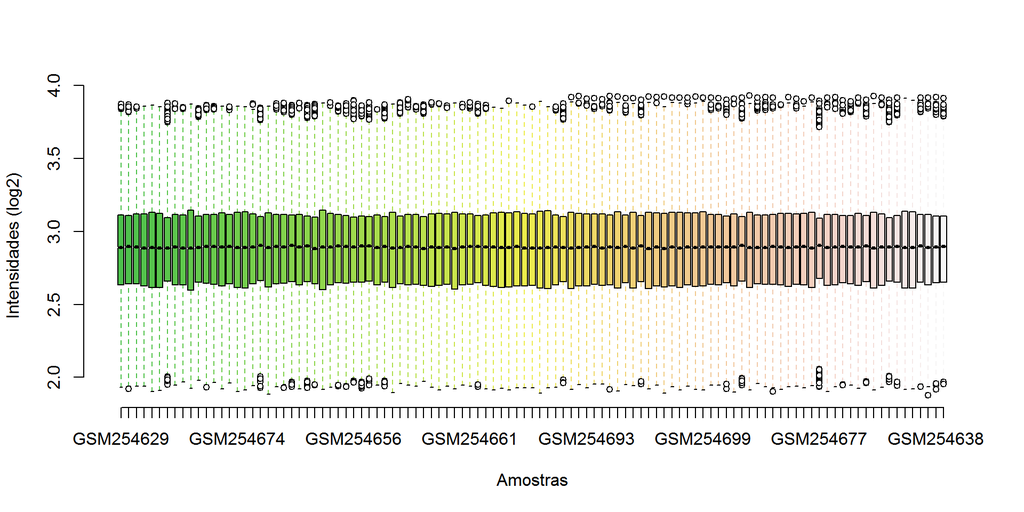

```r
col = terrain.colors(length(pData(eset)$individual), alpha = 0.7)
boxplot(log2(dados), col = col, whiskcol = col, pch = 21, cex = 0.8, xlab = 'Amostras', ylab = 'Intensidades (log2)', notch = TRUE, frame = FALSE)
```

## 2.2 Metadados

```r
vars = pData(eset)
names(vars)
```

```
## [1] "sample"        "tissue"        "individual"    "disease.state" "gender"        "other"
## [7] "description"
```

```r
levels(vars$tissue); levels(vars$individual); levels(vars$disease.state); levels(vars$gender)
```

```
## [1] "normal" "tumor"
```

```
## [1] "current smoker" "former smoker"  "never smoker"
```

```
## [1] "stage I"   "stage II"  "stage III" "stage IV"
```

```
## [1] "female" "male"
```

Na tabela que se segue encontram-se o número de amostras correspondentes às variáveis *tissue* e *individual*, de modo a entender-se quantas das 107 amostras pertencem a cada variável.

```r
addmargins(table(vars$tissue,vars$individual))
```

```
##
##          current smoker former smoker never smoker Sum
##   normal             16            18           15  49
##   tumor              24            18           16  58
##   Sum                40            36           31 107
```

# 3 Preprocessamento

Verificar se existem NAs no expressionset:

```r
sum(which(is.na(dados)))
```

```
## [1] 0
```

O expressionset não contém, portanto, dados omissos. Como verificamos anteriormente os dados já se encontram normalizados e prontos a analisar. Todas as 22283 sondas (features) serão utilizadas nas subsequentes análises, abordagem também optada pelos autores (Landi et al. 2008). Para a análise preditiva e de clustering optou-se por filtrar os dados, reduzindo o numero de features de modo a tornar o processo menos computacionalmente pesado, filtrando-se os genes cujo desvio padrão dos valores de expressão é maior do que duas vezes a mediana dos desvios padrão de todos os genes:

```r
sds = rowSds(dados)
m = median(sds)
eset.f = eset[sds > 2*m]
```

Visualmente corresponde a selecionarmos todos os genes cujo desvio padrão dos valores de expressão se situa para lá da linha verde no histograma abaixo:

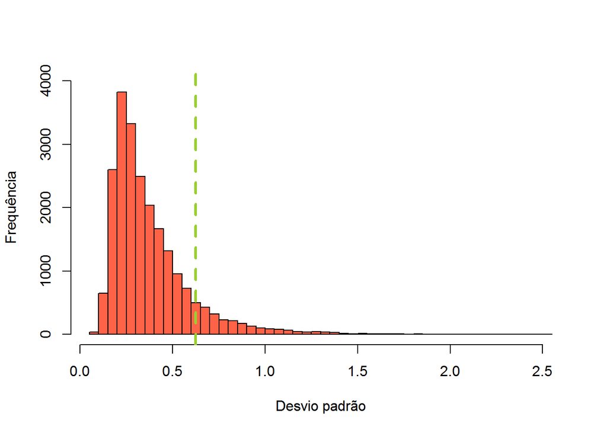

```r
hist(sds,breaks = 50,ylim = c(0,4000),col = "tomato",xlab = 'Desvio padrão',ylab = 'Frequência',main = NULL)
abline(v = m*2, col = "olivedrab3",lwd = 3,lty = 2)
```

# 4 Análise de expressão diferencial e de enriquecimento

As análises estatísticas que se seguem foram realizadas utilzando o package *limma* (Ritchie et al. 2015), uma biblioteca para análise de expressão genética em dados e microarrays, que permite a criação de modelos lineares usando uma extensão Bayes empírica da ANOVA, apropriada para estudos deste tipo. Os genes de interesse identificados por estas análises estatísticas foram então submetidos a uma análise de enriquecimento, de modo a verificar se neste conjunto de genes existe “enriquecimento” estatisticamente significativo nos genes de algum (ou vários) conjuntos de outros genes biologicamente coerentes. Esta última análise foi realizada usando o package *GOstats* (Falcon and Gentleman 2007), que permite testar listas de genes para associação de termos de Gene Ontology (GO).

De modo a tentar encontrar alterações moleculares associadas com o consumo de tabaco, foi realizada uma análise de expressão diferencial entre atuais fumadores e nunca fumadores (**C**/**N**) e antigos fumadores e nunca fumadores (**F**/**N**), para todas as amostras tumorais, para as primeiras fases de tumor (fases I e II) e para todas as amostras de tecido normal. A análise de amostras de tecido tumoral nas primeiras fases poderá ser mais apropriada, uma vez que o estado avançado do tumor poderá causar potenciais alterações de expressão genética. Como critério de significância definiu-se p-value < 0.01 e Fold Change > 1.5.

## 4.1 Nunca fumadores vs. atuais fumadores (Tecido tumoral)

Criação do design para o modelo linear, definindo *never smoker* como referência:

```r
eset.tumor = eset[, eset$tissue == "tumor"]
indivs1 = relevel(eset.tumor$individual, 'never smoker')
design1 = model.matrix(~ indivs1)
head(design1)
```

```
##   (Intercept) indivs1current smoker indivs1former smoker
## 1           1                     0                    0
## 2           1                     0                    0
## 3           1                     0                    0
## 4           1                     0                    0
## 5           1                     0                    0
## 6           1                     0                    0
```

Criação dos modelos lineares de regressão e realização dos testes estatísticos:

```r
fit1 = lmFit(eset.tumor, design1)
fit.bayes1 = eBayes(fit1)
diff1 = topTable(fit.bayes1, coef = 2, 1000, genelist = fit1$genes$NAME)
diff1[1:10,]
```

```
##               logFC AveExpr      t   P.Value adj.P.Val     B
## 203560_at    1.5397   7.377  6.726 8.396e-09 0.0001616 9.702
## 204822_at    1.4822   7.009  6.584 1.451e-08 0.0001616 9.209
## 219787_s_at  1.3950   6.848  5.815 2.732e-07 0.0016185 6.561
## 201088_at    0.8156  10.325  5.799 2.905e-07 0.0016185 6.505
## 204277_s_at -0.4069   6.588 -5.682 4.506e-07 0.0018951 6.109
## 202558_s_at  0.9419   7.537  5.649 5.103e-07 0.0018951 5.996
## 207828_s_at  1.2021   8.557  5.530 7.956e-07 0.0024235 5.595
## 201761_at    0.9958   9.720  5.483 9.501e-07 0.0024235 5.434
## 218053_at    0.6483   9.747  5.465 1.014e-06 0.0024235 5.375
## 204887_s_at  0.7671   6.953  5.446 1.088e-06 0.0024235 5.312
```

De acordo com os testes anteriores verificar quais o genes mais diferentemente expressos, usando o critério de significância definido anteriormente (p-value < 0.01 e Fold Change > 1.5):

```r
treshold = foldchange2logratio (1.5)
upregulated1 = diff1[which(diff1$logFC > treshold & diff1$adj.P.Val < 0.01),]
downregulated1 = diff1[which(diff1$logFC < -treshold & diff1$adj.P.Val < 0.01),]
unlist(mget(rownames(upregulated1),hgu133aSYMBOL))
```

```
##   203560_at   204822_at 219787_s_at   201088_at 202558_s_at 207828_s_at   201761_at   218053_at
##       "GGH"       "TTK"      "ECT2"     "KPNA2"    "HSPA13"     "CENPF"    "MTHFD2"   "PRPF40A"
## 204887_s_at 203362_s_at 218875_s_at 204092_s_at 212020_s_at 222077_s_at 201897_s_at 209172_s_at
##      "PLK4"    "MAD2L1"     "FBXO5"     "AURKA"     "MKI67"   "RACGAP1"     "CKS1B"     "CENPF"
## 201291_s_at   209642_at 208808_s_at   218039_at   201636_at   203418_at   218542_at   201292_at
##     "TOP2A"      "BUB1"     "HMGB2"    "NUSAP1"      "FXR1"     "CCNA2"     "CEP55"     "TOP2A"
## 213911_s_at   204127_at 219918_s_at 209434_s_at   204641_at   209096_at   204146_at 212295_s_at
##     "H2AFZ"      "RFC3"      "ASPM"      "PPAT"      "NEK2"    "UBE2V2"  "RAD51AP1"    "SLC7A1"
## 208079_s_at
##     "AURKA"
```

```r
unlist(mget(rownames(downregulated1),hgu133aSYMBOL))
```

```
##   212256_at   206170_at   201286_at   201525_at   220622_at   204276_at 200810_s_at 200696_s_at
##   "GALNT10"     "ADRB2"      "SDC1"      "APOD"    "LRRC31"       "TK2"     "CIRBP"       "GSN"
```

Verificamos que, para o critério de significância definido, existem 30 genes sobreexpressos (em 33 sondas) e 8 genes (em 8 sondas) subexpressos em tecido tumoral de pacientes fumadores em relação aos nunca fumadores. De seguida será realizada uma análise de enriquecimento de modo a tentar determinar a classe biológica mais provável em que este conjunto de genes se enquadra.

Para esta e as seguintes análises de enriquecimento considerou-se como critério de significância p-value < 0.025. O universo de genes corresponde à totalidade de genes exitentes no expressionset.

**Análise de enriquecimento para os genes sobrexpressos:**

```r
entrezUniverse = unlist(mget(featureNames(eset), hgu133aENTREZID))
selectedEntrezIds1 = unlist(mget(rownames(upregulated1), hgu133aENTREZID))
params1 = new("GOHyperGParams", geneIds = selectedEntrezIds1, universeGeneIds = entrezUniverse,
             annotation = "hgu133a.db", ontology = "BP", pvalueCutoff = 0.025, testDirection = "over")
hgOver1 = hyperGTest(params1)
summary(hgOver1)[1:15,]
```

```
##        GOBPID    Pvalue OddsRatio ExpCount Count Size                                 Term
## 1  GO:0051301 8.112e-15     27.10   1.2978    16  503                        cell division
## 2  GO:0022402 8.392e-15     22.13   2.6910    20 1043                   cell cycle process
## 3  GO:0051302 1.126e-13     36.62   0.5779    12  224          regulation of cell division
## 4  GO:1903047 1.941e-12     18.48   1.8473    16  716           mitotic cell cycle process
## 5  GO:0000278 2.191e-12     17.29   2.2343    17  866                   mitotic cell cycle
## 6  GO:0098813 2.784e-12     40.45   0.3973    10  154       nuclear chromosome segregation
## 7  GO:0007049 3.590e-12     15.42   3.6947    20 1432                           cell cycle
## 8  GO:0051983 6.523e-12     67.41   0.1832     8   71 regulation of chromosome segregation
## 9  GO:0000280 8.040e-12     21.79   1.0733    13  416                     nuclear division
## 10 GO:0010564 1.630e-11     20.52   1.1352    13  440     regulation of cell cycle process
## 11 GO:0048285 1.879e-11     20.27   1.1481    13  445                    organelle fission
## 12 GO:0051726 2.517e-11     15.37   2.1853    16  847             regulation of cell cycle
## 13 GO:0007059 5.083e-11     29.58   0.5315    10  206               chromosome segregation
## 14 GO:0007067 2.998e-10     20.53   0.8643    11  335             mitotic nuclear division
## 15 GO:0000819 4.438e-10     38.10   0.3070     8  119         sister chromatid segregation
```

O resultado anterior aponta para uma existência de “enriquecimento” estatisticamente significativo em genes cujos processos biológicos se relacionam com a divisão/ciclo celular, processo de mitose e segregação dos cromossomas, entre outros. Considerando que uma das caraterísticas mais evidentes no desenvolvimento do cancro passa pela rápida e descontrolada proliferação celular estes resultados vão de encontro ao que seria de esperar. De facto, entre os genes identificados estão o “TTK” (codifica proteína essecial no alinhamento cromossomal durante a mitose (Mills et al. 1992)), “ECT2” (pensa-se que poderá ter um papel importante na regulação da citocinese (Tatsumoto et al. 1999)) e “CENPF” (indispensável para a função do cinetócoro e segregação cromossomal durante a mitose (Liao et al. 1995)), entre outros, reforçando o resultado obtido.

**Análise de enriquecimento para os genes subexpressos:**

```r
selectedEntrezIds2 = unlist(mget(rownames(downregulated1), hgu133aENTREZID))
params2 = new("GOHyperGParams", geneIds = selectedEntrezIds2, universeGeneIds = entrezUniverse,
              annotation = "hgu133a.db", ontology = "BP", pvalueCutoff = 0.025, testDirection = "over")
hgOver2 = hyperGTest(params2)
summary(hgOver2)[c(1:6,8:14),] #linha 7 demasiado longa
```

```
##        GOBPID    Pvalue OddsRatio  ExpCount Count Size                                               Term
## 1  GO:0031099 0.0001041     51.25 0.1027580     3  165                                       regeneration
## 2  GO:0009409 0.0002695    114.81 0.0255338     2   41                                   response to cold
## 3  GO:0042060 0.0003350     21.89 0.4041815     4  649                                      wound healing
## 4  GO:0007568 0.0003863     32.42 0.1600534     3  257                                              aging
## 5  GO:0042246 0.0004178     91.30 0.0317616     2   51                                tissue regeneration
## 6  GO:1901137 0.0004973     19.61 0.4477758     4  719       carbohydrate derivative biosynthetic process
## 8  GO:0044855 0.0006228       Inf 0.0006228     1    1                  plasma membrane raft distribution
## 9  GO:0044856 0.0006228       Inf 0.0006228     1    1                  plasma membrane raft localization
## 10 GO:0044858 0.0006228       Inf 0.0006228     1    1                  plasma membrane raft polarization
## 11 GO:0046092 0.0006228       Inf 0.0006228     1    1                    deoxycytidine metabolic process
## 12 GO:0060588 0.0006228       Inf 0.0006228     1    1 negative regulation of lipoprotein lipid oxidation
## 13 GO:1901526 0.0006228       Inf 0.0006228     1    1              positive regulation of macromitophagy
## 14 GO:1903906 0.0006228       Inf 0.0006228     1    1    regulation of plasma membrane raft polarization
```

## 4.2 Nunca fumadores vs. antigos fumadores (Tecido tumoral)

O design usado neste caso é o mesmo que no caso anterior. Criação dos modelos lineares de regressão e realização dos testes estatísticos:

```r
fit2 = lmFit(eset.tumor, design1)
fit.bayes2 = eBayes(fit2)
diff2 = topTable(fit.bayes2, coef = 3, 1000, genelist = fit2$genes$NAME)
diff2[1:10,]
```

```
##               logFC AveExpr      t   P.Value adj.P.Val      B
## 218222_x_at  0.3235   7.851  4.785 1.214e-05    0.1670 2.6970
## 38671_at    -0.8171   9.479 -4.706 1.608e-05    0.1670 2.4705
## 202134_s_at  0.3912   8.473  4.611 2.248e-05    0.1670 2.2005
## 204862_s_at -0.7199   8.753 -4.415 4.459e-05    0.1968 1.6484
## 209856_x_at  0.3121   8.339  4.275 7.213e-05    0.1968 1.2607
## 213440_at   -0.4512   6.998 -4.232 8.344e-05    0.1968 1.1432
## 221728_x_at -2.4508   7.781 -4.221 8.659e-05    0.1968 1.1134
## 214218_s_at -2.2003   6.034 -4.197 9.376e-05    0.1968 1.0492
## 200810_s_at -0.6214   9.844 -4.182 9.870e-05    0.1968 1.0078
## 211089_s_at  0.3824   7.030  4.103 1.286e-04    0.1968 0.7947
```

De acordo com os testes anteriores verificar quais o genes mais diferentemente expressos, usando o critério de significância já definido:

```r
upregulated2 = diff2[which(diff2$logFC > treshold & diff2$adj.P.Val < 0.01),]
downregulated2 = diff2[which(diff2$logFC < -treshold & diff2$adj.P.Val < 0.01),]
unlist(mget(rownames(upregulated2),hgu133aSYMBOL))
```

```r
unlist(mget(rownames(downregulated2),hgu133aSYMBOL))
```

Verificamos que, para o critério de significância definido, não existem genes sobre ou subexpressos em tecidos provenientes de antigos fumadores relativamente aos tecido provenientes de nunca fumadores.

## 4.3 Nunca fumadores vs. atuais fumadores (Tecido tumoral - fases I e II)

Criação do design para o modelo linear, definindo *never smoker* como referência:

```r
eset.stumor = eset[, eset$tissue == "tumor" & (eset$disease.state == 'stage I' | eset$disease.state == 'stage II')]
indivs2 = relevel(eset.stumor$individual, 'never smoker')
design2 = model.matrix(~ indivs2)
head(design2)
```

```
##   (Intercept) indivs2current smoker indivs2former smoker
## 1           1                     0                    0
## 2           1                     0                    0
## 3           1                     0                    0
## 4           1                     0                    0
## 5           1                     0                    0
## 6           1                     0                    0
```

Criação dos modelos lineares de regressão e realização dos testes estatísticos:

```r
fit3 = lmFit(eset.stumor, design2)
fit.bayes3 = eBayes(fit3)
diff3 = topTable(fit.bayes3, coef = 2, 1000, genelist = fit3$genes$NAME)
head(diff3)
```

```
##             logFC AveExpr      t   P.Value adj.P.Val     B
## 206170_at -1.0444   8.265 -6.648 4.188e-08 0.0009333 8.228
## 203560_at  1.7140   7.452  6.329 1.218e-07 0.0013566 7.280
## 209667_at -0.7054   8.689 -5.776 7.764e-07 0.0037178 5.627
## 204822_at  1.5852   7.058  5.730 9.038e-07 0.0037178 5.491
## 208760_at -0.9523   8.180 -5.727 9.129e-07 0.0037178 5.482
## 201088_at  0.8608  10.360  5.699 1.003e-06 0.0037178 5.397
```

De acordo com os testes anteriores verificar quais o genes mais diferentemente expressos, usando o critério de significância já definido:

```r
upregulated3 = diff3[which(diff3$logFC > treshold & diff3$adj.P.Val < 0.01),]
downregulated3 = diff3[which(diff3$logFC < -treshold & diff3$adj.P.Val < 0.01),]
unlist(mget(rownames(upregulated3),hgu133aSYMBOL))
```

```
##   203560_at   204822_at   201088_at 207828_s_at 219787_s_at   218542_at   201761_at   201292_at
##       "GGH"       "TTK"     "KPNA2"     "CENPF"      "ECT2"     "CEP55"    "MTHFD2"     "TOP2A"
## 204887_s_at 201291_s_at
##      "PLK4"     "TOP2A"
```

```r
unlist(mget(rownames(downregulated3),hgu133aSYMBOL))
```

```
##   206170_at   209667_at   208760_at   201286_at   220622_at   213244_at 208704_x_at 204519_s_at
##     "ADRB2"      "CES2"     "UBE2I"      "SDC1"    "LRRC31"    "SCAMP4"     "APLP2"      "PLLP"
## 200696_s_at
##       "GSN"
```

Verificamos que, para o critério de significância definido, existem 9 genes sobreexpressos (em 10 sondas) e 9 genes subexpressos (em 9 sondas) em tecido tumoral de pacientes fumadores em relação aos nunca fumadores. De seguida será realizada uma análise de enriquecimento de modo a tentar determinar a classe biológica mais provável em que este conjunto de genes se enquadra.

**Análise de enriquecimento para os genes sobrexpressos:**

```r
selectedEntrezIds3 = unlist(mget(rownames(upregulated3), hgu133aENTREZID))
params3 = new("GOHyperGParams", geneIds = selectedEntrezIds3, universeGeneIds = entrezUniverse,
              annotation = "hgu133a.db", ontology = "BP", pvalueCutoff = 0.025, testDirection = "over")
hgOver3 = hyperGTest(params3)
summary(hgOver3)[1:15,]
```

```
##        GOBPID    Pvalue OddsRatio ExpCount Count Size                                             Term
## 1  GO:0098813 4.048e-06     59.10  0.12331     4  154                   nuclear chromosome segregation
## 2  GO:0051304 1.128e-05     99.78  0.04724     3   59                            chromosome separation
## 3  GO:0007059 1.285e-05     43.68  0.16495     4  206                           chromosome segregation
## 4  GO:0051301 1.909e-05     26.94  0.40276     5  503                                    cell division
## 5  GO:0051983 1.974e-05     82.08  0.05685     3   71             regulation of chromosome segregation
## 6  GO:0022402 4.135e-05     19.66  0.83514     6 1043                               cell cycle process
## 7  GO:0000819 9.279e-05     47.91  0.09528     3  119                     sister chromatid segregation
## 8  GO:1903047 1.051e-04     18.50  0.57331     5  716                       mitotic cell cycle process
## 9  GO:0006760 1.306e-04    160.16  0.01762     2   22 folic acid-containing compound metabolic process
## 10 GO:0042558 1.980e-04    128.07  0.02162     2   27  pteridine-containing compound metabolic process
## 11 GO:0007093 2.033e-04     36.44  0.12411     3  155                    mitotic cell cycle checkpoint
## 12 GO:0051726 2.342e-04     15.42  0.67820     5  847                         regulation of cell cycle
## 13 GO:0010564 2.495e-04     19.81  0.35231     4  440                 regulation of cell cycle process
## 14 GO:0007049 2.522e-04     13.75  1.14662     6 1432                                       cell cycle
## 15 GO:0000278 2.601e-04     15.06  0.69342     5  866                               mitotic cell cycle
```

O resultado anterior aponta para uma existência de “enriquecimento” estatisticamente significativo em genes cujos processos biológicos se relacionam com a divisão/ciclo celular, processo de mitose e regulação/segregação cromossomal, entre outros. Estes resultados são, de facto, semelhantes aqueles obtidos quando consideramos todas as fases tumorais. Também aqui os genes mencionados anteriormente estão entre os mais sobrexpressos, cuja função se relaciona com o resultado obtido. No entanto quando apenas consideramos as primeiras fases tumorais (fases I e II) o nr de genes sobrexpressos diminui, o que poderá estar relacionado com o facto mencionado anteriormente de o estado avançado do tumor (não considerado aqui) poder causar potenciais alterações na expressão genética.

**Análise de enriquecimento para os genes subexpressos:**

```r
selectedEntrezIds4 = unlist(mget(rownames(downregulated3), hgu133aENTREZID))
params4 = new("GOHyperGParams", geneIds = selectedEntrezIds4, universeGeneIds = entrezUniverse,
              annotation = "hgu133a.db", ontology = "BP", pvalueCutoff = 0.025, testDirection = "over")
hgOver4 = hyperGTest(params4)
summary(hgOver4)[1:15,] #linhas demasiado longas
```

```
##        GOBPID    Pvalue OddsRatio  ExpCount Count Size
## 1  GO:0003059 0.0007117       Inf 0.0007117     1    1
## 2  GO:0044855 0.0007117       Inf 0.0007117     1    1
## 3  GO:0044856 0.0007117       Inf 0.0007117     1    1
## 4  GO:0044858 0.0007117       Inf 0.0007117     1    1
## 5  GO:1901526 0.0007117       Inf 0.0007117     1    1
## 6  GO:1903182 0.0007117       Inf 0.0007117     1    1
## 7  GO:1903755 0.0007117       Inf 0.0007117     1    1
## 8  GO:1903906 0.0007117       Inf 0.0007117     1    1
## 9  GO:1904923 0.0007117       Inf 0.0007117     1    1
## 10 GO:1904925 0.0007117       Inf 0.0007117     1    1
## 11 GO:0030198 0.0013603     19.46 0.2412811     3  339
## 12 GO:0043062 0.0013720     19.40 0.2419929     3  340
## 13 GO:0002032 0.0014230   1604.43 0.0014235     1    2
## 14 GO:0048627 0.0014230   1604.43 0.0014235     1    2
```

[output cut: 17 more lines]

A análise de enriquecimento para genes subexpressos aponta para uma existência de “enriquecimento” estatisticamente significativo em genes cujos processos biológicos se relacionam com distriuição/localização/polarização de *rafts* na membrana plasmática, regulação de macromitofagia (forma especializada de autofagia pela qual se degradam e reciclam selectivamente as mitocondrias) e ainda com a organização da matrix extracelular. Sendo a matriz extracelular constituida por um conjunto de moléculas que conferem suporte estrutural e bioquímico às células circundantes, alguns dos genes identificados poderão estar relacionados com a metastização do tumor. Uma outra caraterística comum a células cancerígenas consiste numa maior resistência à apoptose mitocondrial, pelo que seria de esperar genes que regulam positivamente este processo estarem subexpressos. Entre os genes mais subespressos estão o “ADRB2” (envolvido no processo de adesão celular (Boulay et al. 2012)) e “SDC1” (envolvido com a matrix celular e processo de adesão celular (Lories et al. 1992)), entre outros.

## 4.4 Nunca fumadores vs. antigos fumadores (Tecido tumoral - fases I e II)

O design usado neste caso é o mesmo que no caso anterior. Criação dos modelos lineares de regressão e realização dos testes estatísticos:

```r
fit4 = lmFit(eset.stumor, design2)
fit.bayes4 = eBayes(fit4)
diff4 = topTable(fit.bayes4, coef = 3, 1000, genelist = fit4$genes$NAME)
head(diff4)
```

```
##               logFC AveExpr      t   P.Value adj.P.Val     B
## 206170_at   -0.8622   8.265 -5.053 8.515e-06   0.07561 3.068
## 209667_at   -0.6662   8.689 -5.023 9.415e-06   0.07561 2.987
## 208760_at   -0.8991   8.180 -4.979 1.088e-05   0.07561 2.870
## 213509_x_at -0.5529   9.332 -4.911 1.357e-05   0.07561 2.691
## 204519_s_at -0.9484   8.133 -4.793 1.991e-05   0.08875 2.380
## 212326_at   -0.6100   7.631 -4.660 3.061e-05   0.11366 2.030
```

De acordo com os testes anteriores verificar quais o genes mais diferentemente expressos, usando o critério de significância já definido:

```r
upregulated4 = diff4[which(diff4$logFC > treshold & diff4$adj.P.Val < 0.01),]
downregulated4 = diff4[which(diff4$logFC < -treshold & diff4$adj.P.Val < 0.01),]
unlist(mget(rownames(upregulated4),hgu133aSYMBOL))
```

```r
unlist(mget(rownames(downregulated4),hgu133aSYMBOL))
```

Verificamos que, para o critério de significância definido, não existem genes sobre ou subexpressos em tecidos provenientes de antigos fumadores relativamente aos tecido provenientes de nunca fumadores.

## 4.5 Nunca fumadores vs. atuais fumadores (Tecido normal)

Criação do design para o modelo linear, definindo *never smoker* como referência:

```r
eset.normal = eset[, eset$tissue == "normal"]
indivs3 = relevel(eset.normal$individual, 'never smoker')
design3 = model.matrix(~ indivs3)
head(design3)
```

```
##   (Intercept) indivs3current smoker indivs3former smoker
## 1           1                     0                    0
## 2           1                     0                    0
## 3           1                     0                    0
## 4           1                     0                    0
## 5           1                     0                    0
## 6           1                     0                    0
```

Criação dos modelos lineares de regressão e realização dos testes estatísticos:

```r
fit5 = lmFit(eset.normal, design3)
fit.bayes5 = eBayes(fit5)
diff5 = topTable(fit.bayes5, coef = 2, 1000, genelist = fit5$genes$NAME)
head(diff5)
```

```
##               logFC AveExpr      t   P.Value adj.P.Val      B
## 202437_s_at  2.1955   7.866  8.956 5.858e-12 1.305e-07 16.130
## 202436_s_at  1.8094   9.424  8.165 9.411e-11 1.049e-06 13.697
## 205576_at    1.3752   6.518  7.070 4.721e-09 3.507e-05 10.221
## 202435_s_at  1.4417   8.559  6.887 9.134e-09 5.089e-05  9.631
## 220911_s_at -0.4782   9.089 -6.536 3.224e-08 1.437e-04  8.500
## 211276_at   -0.9230   6.290 -5.888 3.291e-07 1.167e-03  6.409
```

De acordo com os testes anteriores verificar quais o genes mais diferentemente expressos, usando o critério de significância já definido:

```r
upregulated5 = diff5[which(diff5$logFC > treshold & diff5$adj.P.Val < 0.01),]
downregulated5 = diff5[which(diff5$logFC < -treshold & diff5$adj.P.Val < 0.01),]
unlist(mget(rownames(upregulated5),hgu133aSYMBOL))
```

```
## 202437_s_at 202436_s_at   205576_at 202435_s_at 221266_s_at 220625_s_at   204580_at 206700_s_at
##    "CYP1B1"    "CYP1B1"  "SERPIND1"    "CYP1B1"   "DCSTAMP"      "ELF5"     "MMP12"     "KDM5D"
##   219890_at
##    "CLEC5A"
```

```r
unlist(mget(rownames(downregulated5),hgu133aSYMBOL))
```

```
##   211276_at   205433_at   213071_at 204428_s_at 205109_s_at   202746_at   204589_at 208096_s_at
##    "TCEAL2"      "BCHE"       "DPT"      "LCAT"   "ARHGEF4"     "ITM2A"     "NUAK1"   "COL21A1"
##   213456_at   202908_at 203349_s_at
##   "SOSTDC1"      "WFS1"      "ETV5"
```

Verificamos que, para o critério de significância definido, existem 7 genes sobreexpressos (em 9 sondas) e 11 genes subexpressos (em 11 sondas) em tecido normal de pacientes fumadores em relação aos nunca fumadores. De seguida será realizada uma análise de enriquecimento de modo a tentar determinar a classe biológica mais provável em que este conjunto de genes se enquadra.

**Análise de enriquecimento para os genes sobrexpressos:**

```r
selectedEntrezIds5 = unlist(mget(rownames(upregulated5), hgu133aENTREZID))
params5 = new("GOHyperGParams", geneIds = selectedEntrezIds5, universeGeneIds = entrezUniverse,
              annotation = "hgu133a.db", ontology = "BP", pvalueCutoff = 0.025, testDirection = "over")
hgOver5 = hyperGTest(params5)
summary(hgOver5)[c(1:12,14:15),] #linha 13 demasiado longa
```

```
##        GOBPID   Pvalue OddsRatio ExpCount Count Size                                            Term
## 1  GO:0002930 0.001245    1872.0 0.001246     1    2                 trabecular meshwork development
## 2  GO:0034241 0.001245    1872.0 0.001246     1    2        positive regulation of macrophage fusion
## 3  GO:0001712 0.001867     935.9 0.001868     1    3                 ectodermal cell fate commitment
## 4  GO:0008218 0.001867     935.9 0.001868     1    3                                 bioluminescence
## 5  GO:0034238 0.001867     935.9 0.001868     1    3                               macrophage fusion
## 6  GO:0034239 0.001867     935.9 0.001868     1    3                 regulation of macrophage fusion
## 7  GO:0072674 0.001867     935.9 0.001868     1    3         multinuclear osteoclast differentiation
## 8  GO:0072675 0.001867     935.9 0.001868     1    3                               osteoclast fusion
## 9  GO:0071603 0.002489     623.9 0.002491     1    4                  endothelial cell-cell adhesion
## 10 GO:0001705 0.003111     467.9 0.003114     1    5                              ectoderm formation
## 11 GO:0002457 0.003111     467.9 0.003114     1    5      T cell antigen processing and presentation
## 12 GO:0045657 0.003111     467.9 0.003114     1    5 positive regulation of monocyte differentiation
## 14 GO:0061304 0.003111     467.9 0.003114     1    5              retinal blood vessel morphogenesis
## 15 GO:0034720 0.003732     374.3 0.003737     1    6                     histone H3-K4 demethylation
```

O resultado anterior aponta para uma existência de “enriquecimento” estatisticamente significativo em genes cujos processos biológicos se relacionam com a defesa celular e resposta imunológica. Entre os genes mais sobrexpressos, como seria de esperar, encontra-se o “CYP1B1”, um gene que se sabe ser induzido pelo consumo de tabaco (Lampe et al. 2004) e cuja enzima codificada metaboliza procarcinógenos, substâncias químicas que se tornam carcinógenos após metabolizadas.

**Análise de enriquecimento para os genes subexpressos:**

```r
selectedEntrezIds6 = unlist(mget(rownames(downregulated5), hgu133aENTREZID))
params6 = new("GOHyperGParams", geneIds = selectedEntrezIds6, universeGeneIds = entrezUniverse,
              annotation = "hgu133a.db", ontology = "BP", pvalueCutoff = 0.025, testDirection = "over")
hgOver6 = hyperGTest(params6)
summary(hgOver6)[c(1:4,6:15),-4] #linha 5 demasiado longa
```

```
##        GOBPID    Pvalue OddsRatio Count Size                                                     Term
## 1  GO:0060603 0.0004417     82.32     2   36                         mammary gland duct morphogenesis
## 2  GO:0060443 0.0008193     59.48     2   49                              mammary gland morphogenesis
## 3  GO:0046448 0.0008897       Inf     1    1                       tropane alkaloid metabolic process
## 4  GO:0050783 0.0008897       Inf     1    1                                cocaine metabolic process
## 6  GO:0042439 0.0013517     45.77     2   63       ethanolamine-containing compound metabolic process
## 7  GO:0061180 0.0014382     44.31     2   65                     mammary gland epithelium development
## 8  GO:0090107 0.0017786   1247.67     1    2 regulation of high-density lipoprotein particle assembly
## 9  GO:1903891 0.0017786   1247.67     1    2    regulation of ATF6-mediated unfolded protein response
## 10 GO:0014016 0.0026669    623.78     1    3                               neuroblast differentiation
## 11 GO:0019695 0.0026669    623.78     1    3                                choline metabolic process
## 12 GO:0042078 0.0026669    623.78     1    3                             germ-line stem cell division
## 13 GO:0048133 0.0026669    623.78     1    3             male germ-line stem cell asymmetric division
## 14 GO:0060648 0.0026669    623.78     1    3                          mammary gland bud morphogenesis
## 15 GO:0098728 0.0026669    623.78     1    3                   germline stem cell asymmetric division
```

A análise de enriquecimento para genes subexpressos aponta para uma existência de “enriquecimento” estatisticamente significativo em genes cujos processos biológicos se relacionam com processos metabólicos e, interessantemente, com a morfogénese/deseonvolvimento da glândula mamária. Embora este estudo seja em adenocarcinoma pulmonar, não deixa de ser interessante verificar que, em tecido normal de fumadores, haja expressão diferencial em genes relacionados com a morfogénese/desenvolvimento da glândula mamária, uma vez que se pensa que o consumo do tabaco está relacionado com o surgimento do cancro da mama (Catsburg et al. 2014). No entanto, poderá tratar-se apenas de uma coincidência. Entre os genes mais subespressos estão o “DPT”, “ARHGEF4” e “NUAK1”, todos eles relacionados com o processo de adesão celular (Superti-Furga et al. 1993; Thiesen et al. 2000; Hou et al. 2011).

## 4.6 Nunca fumadores vs. antigos fumadores (Tecido normal)

O design usado neste caso é o mesmo que no caso anterior. Criação dos modelos lineares de regressão e realização dos testes estatísticos:

```r
fit6 = lmFit(eset.normal, design3)
fit.bayes6 = eBayes(fit6)
diff6 = topTable(fit.bayes6, coef = 3, 1000, genelist = fit6$genes$NAME)
head(diff6)
```

```
##               logFC AveExpr      t   P.Value adj.P.Val     B
## 206700_s_at  1.6509   8.795  6.499 3.679e-08 0.0008198 4.921
## 214218_s_at -2.7029   5.673 -5.965 2.503e-07 0.0024288 3.798
## 201909_at    3.2166  10.443  5.818 4.226e-07 0.0024288 3.486
## 205000_at    2.9676   7.875  5.749 5.390e-07 0.0024288 3.340
## 221728_x_at -3.1062   7.386 -5.746 5.450e-07 0.0024288 3.334
## 203992_s_at -0.5797   7.818 -4.891 1.086e-05 0.0397467 1.506
```

De acordo com os testes anteriores verificar quais o genes mais diferentemente expressos, usando o critério de significância já definido:

```r
upregulated6 = diff6[which(diff6$logFC > treshold & diff6$adj.P.Val < 0.01),]
downregulated6 = diff6[which(diff6$logFC < -treshold & diff6$adj.P.Val < 0.01),]
unlist(mget(rownames(upregulated6),hgu133aSYMBOL))
```

```
## 206700_s_at   201909_at   205000_at
##     "KDM5D"    "RPS4Y1"     "DDX3Y"
```

```r
unlist(mget(rownames(downregulated6),hgu133aSYMBOL))
```

```
## 214218_s_at 221728_x_at
##      "XIST"      "XIST"
```

Verificamos que, para o critério de significância definido, existem 3 genes sobreexpressos (em 3 sondas) e 1 gene subexpressos (em duas sondas) em tecido normal de pacientes antigos fumadores em relação aos nunca fumadores. De seguida será realizada uma análise de enriquecimento de modo a tentar determinar a classe biológica mais provável em que este conjunto de genes se enquadra.

**Análise de enriquecimento para os genes sobrexpressos:**

```r
selectedEntrezIds7 = unlist(mget(rownames(upregulated6), hgu133aENTREZID))
params7 = new("GOHyperGParams", geneIds = selectedEntrezIds7, universeGeneIds = entrezUniverse,
              annotation = "hgu133a.db", ontology = "BP", pvalueCutoff = 0.025, testDirection = "over")
hgOver7 = hyperGTest(params7)
summary(hgOver7)[1:15,]
```

```
##        GOBPID    Pvalue OddsRatio ExpCount Count Size                                       Term
## 1  GO:0006413 0.0009528    110.37 0.053915     2  202                   translational initiation
## 2  GO:0002457 0.0013340   1404.12 0.001335     1    5 T cell antigen processing and presentation
## 3  GO:0034720 0.0016007   1123.20 0.001601     1    6                histone H3-K4 demethylation
## 4  GO:0006412 0.0050043     46.44 0.124377     2  466                                translation
## 5  GO:0043043 0.0053929     44.63 0.129181     2  484               peptide biosynthetic process
## 6  GO:0043604 0.0067159     39.70 0.144395     2  541                 amide biosynthetic process
## 7  GO:0070076 0.0069241    224.24 0.006940     1   26               histone lysine demethylation
## 8  GO:0016577 0.0071897    215.60 0.007206     1   27                      histone demethylation
## 9  GO:0006482 0.0077209    200.16 0.007740     1   29                      protein demethylation
## 10 GO:0008214 0.0077209    200.16 0.007740     1   29                       protein dealkylation
## 11 GO:0006518 0.0079648     36.22 0.157473     2  590                  peptide metabolic process
## 12 GO:0010501 0.0085174    180.74 0.008541     1   32          RNA secondary structure unwinding
## 13 GO:0043603 0.0117063     29.39 0.191637     2  718           cellular amide metabolic process
## 14 GO:0070988 0.0127579    119.04 0.012811     1   48                              demethylation
## 15 GO:0002456 0.0180415     83.36 0.018149     1   68                   T cell mediated immunity
```

O resultado anterior aponta para uma existência de “enriquecimento” estatisticamente significativo em genes cujos processos biológicos se relacionam com a defesa celular e resposta imunológica (“KDM5D” (Rezvani and Barrett 2008),“DDX3Y” (Rosinski et al. 2008)), biossíntese e processamento de péptidos e histonas (“RPS4Y1”, (Andrés et al. 2008)).

**Análise de enriquecimento para os genes subexpressos:**

```r
selectedEntrezIds8 = unlist(mget(rownames(downregulated6), hgu133aENTREZID))
params8 = new("GOHyperGParams", geneIds = selectedEntrezIds8, universeGeneIds = entrezUniverse,
              annotation = "hgu133a.db", ontology = "BP", pvalueCutoff = 0.025, testDirection = "over")
hgOver8 = hyperGTest(params8)
```

```
## Error in getGoToEntrezMap_db(p): genes being tested do not have corresponding GO terms
```

Como podemos verificar, esta análise não pode ser realizado pois o gene a ser testado, “XIST”, não tem nenhum termo GO correspondente. Este gene está envolvido na inativação de uma das cópias do cromossoma X em mamíferos do género feminino.

## 4.7 Antigos fumadores vs. atuais fumadores (Tecido tumoral - fases I e II)

De modo a verificar se o padrão verificado entre atuais fumadores/nunca fumadores também é verificado para antigos fumadores foi realizada uma análise de expressão genética entre atuais fumadores e antigos fumadores em tecidos tumorais nas primeiras fases.

Criação do design para o modelo linear (*current smoker* como referência):

```r
design4 = model.matrix(~ eset.stumor$individual)
head(design4)
```

```
##   (Intercept) eset.stumor$individualformer smoker eset.stumor$individualnever smoker
## 1           1                                   0                                  1
## 2           1                                   0                                  1
## 3           1                                   0                                  1
## 4           1                                   0                                  1
## 5           1                                   0                                  1
## 6           1                                   0                                  1
```

Criação dos modelos lineares de regressão e realização dos testes estatísticos:

```r
fit7 = lmFit(eset.stumor, design4)
fit.bayes7 = eBayes(fit7)
diff7 = topTable(fit.bayes7, coef = 2, 1000, genelist = fit7$genes$NAME)
head(diff7)
```

```
##               logFC AveExpr      t   P.Value adj.P.Val       B
## 207788_s_at  0.4580   6.928  4.569 4.104e-05    0.6568 -0.9912
## 212846_at   -0.5195   8.854 -4.148 1.553e-04    0.6568 -1.5285
## 212729_at    0.4508   7.562  4.115 1.717e-04    0.6568 -1.5695
## 203560_at   -1.0166   7.452 -4.081 1.912e-04    0.6568 -1.6136
## 214326_x_at  0.6461   7.294  4.073 1.957e-04    0.6568 -1.6232
## 204395_s_at  0.2559   8.719  4.047 2.120e-04    0.6568 -1.6560
```

De acordo com os testes anteriores verificar quais o genes mais diferentemente expressos, usando o critério de significância já definido:

```r
upregulated7 = diff7[which(diff7$logFC > treshold & diff7$adj.P.Val < 0.01),]
downregulated7 = diff7[which(diff7$logFC < -treshold & diff7$adj.P.Val < 0.01),]
unlist(mget(rownames(upregulated7),hgu133aSYMBOL))
```

```r
unlist(mget(rownames(downregulated7),hgu133aSYMBOL))
```

Verificamos que, para o critério de significância definido, não existem genes diferencialmente expressos entre antigos fumadores relativamente a atuais fumadores. Isto poderá indicar que embora os pacientes já tivessem deixado de fumar há algum tempo as alterações a nível dos genes se manteve.

## 4.8 Tabela resumo da análise de expressão diferencial

Na seguinte tabela encontram-se resumidos o nr de genes identificados durante as análises de expressão diferencial anteriores:

**Tabela 1** - Número de sondas e genes (sobre e subexpressos) diferenciando atuais fumadores (**C**) de nunca fumadores (**N**) e antigos fumadores (**F**) de nunca fumadores em todas as amostras tumorais, amostras tumorais em fase I ou II e amostras de tecido normal. Como critério de significância para análise definiu-se p-value < 0.01 e Fold Change > 1.5.

| Tecido | Tumor |  | Tumor (fases I e II) |  | Normal |  |
| --- | --- | --- | --- | --- | --- | --- |
| **Condição** | **24C vs 16N** | **18F vs 16N** | **20C vs 10N** | **13F vs 10N** | **16C vs 15N** | **18F vs 15N** |
| **Genes Sobr** | 30 | 0 | 9 | 0 | 7 | 3 |
| **Sondas Sobr** | 33 | 0 | 10 | 0 | 9 | 3 |
| **Genes Sub** | 8 | 0 | 9 | 0 | 11 | 1 |
| **Sondas Sub** | 8 | 0 | 9 | 0 | 11 | 2 |

Uma análise de expressão diferencial foi também relizada entre amostras provenientes de tecido normal vs. tecido tumoral, de modo a obter-se uma visão geral expressão de genes nos dois tecidos sem ter em conta o perfil do paciente.

Criação do design para o modelo linear (*normal* como referência):

```r
design5 = model.matrix(~ eset$tissue)
head(design5)
```

```
##   (Intercept) eset$tissuetumor
## 1           1                1
## 2           1                1
## 3           1                1
## 4           1                1
## 5           1                1
## 6           1                1
```

Criação dos modelos lineares de regressão e realização dos testes estatísticos:

```r
fit8 = lmFit(eset, design5)
fit.bayes8 = eBayes(fit8)
diff8 = topTable(fit.bayes8, coef = 2, 1000, genelist = fit8$genes$NAME)
head(diff8)
```

```
##              logFC AveExpr      t   P.Value adj.P.Val     B
## 209074_s_at -3.372   8.995 -24.01 3.231e-45 7.200e-41 92.44
## 209555_s_at -2.417   8.261 -22.42 1.588e-42 1.769e-38 86.33
## 204396_s_at -2.388   8.677 -22.19 3.992e-42 2.965e-38 85.42
## 206209_s_at -2.554   8.082 -22.00 8.567e-42 4.773e-38 84.66
## 204271_s_at -2.227   8.784 -21.94 1.096e-41 4.886e-38 84.42
## 204677_at   -2.620   8.004 -21.82 1.771e-41 6.577e-38 83.94
```

De acordo com os testes anteriores verificar quais o genes mais diferentemente expressos, usando o critério de significância já definido:

```r
upregulated8 = diff8[which(diff8$logFC > treshold & diff8$adj.P.Val < 0.01),]
downregulated8 = diff8[which(diff8$logFC < -treshold & diff8$adj.P.Val < 0.01),]
length(unlist(mget(rownames(upregulated8),hgu133aSYMBOL))) #nr sondas
```

```
## [1] 284
```

```r
length(unique(unlist(mget(rownames(upregulated8),hgu133aSYMBOL)))) #nr genes
```

```
## [1] 227
```

```r
length(unlist(mget(rownames(downregulated8),hgu133aSYMBOL)))
```

```
## [1] 636
```

```r
length(unique(unlist(mget(rownames(downregulated8),hgu133aSYMBOL))))
```

```
## [1] 481
```

Devido ao elevado número de genes no resultado optou-se por apresentar o número total de genes em vez da lista de genes em si. Verificamos que, para o critério de significância definido, existem 227 genes sobreexpressos (em 284 sondas) e 481 genes subexpressos (em 636 sondas) em tecido tumoral relativamente ao tecido normal. De seguida será realizada uma análise de enriquecimento de modo a tentar determinar a classe biológica mais provável em que este conjunto de genes se enquadra.

**Análise de enriquecimento para os genes sobrexpressos:**

```r
selectedEntrezIds9 = unlist(mget(rownames(upregulated8), hgu133aENTREZID))
params9 = new("GOHyperGParams", geneIds = selectedEntrezIds9, universeGeneIds = entrezUniverse,
              annotation = "hgu133a.db", ontology = "BP", pvalueCutoff = 0.025, testDirection = "over")
hgOver9 = hyperGTest(params9)
summary(hgOver9)[1:15,]
```

```
##        GOBPID    Pvalue OddsRatio ExpCount Count Size                                            Term
## 1  GO:0044770 2.554e-09     4.163   8.1677    29  427                     cell cycle phase transition
## 2  GO:0044772 4.142e-09     4.183   7.8234    28  409             mitotic cell cycle phase transition
## 3  GO:0000278 4.724e-09     3.099  16.5649    43  866                              mitotic cell cycle
## 4  GO:1903047 2.425e-08     3.167  13.6957    37  716                      mitotic cell cycle process
## 5  GO:0009132 4.099e-08     8.283   1.8746    13   98        nucleoside diphosphate metabolic process
## 6  GO:0046939 4.507e-08     9.251   1.5685    12   82                      nucleotide phosphorylation
## 7  GO:0046365 7.340e-08    11.902   1.0520    10   55                monosaccharide catabolic process
## 8  GO:0006007 1.862e-07    16.349   0.6504     8   34                       glucose catabolic process
## 9  GO:0019320 2.546e-07    12.307   0.9181     9   48                        hexose catabolic process
## 10 GO:0009123 3.883e-07     4.683   4.3803    18  229      nucleoside monophosphate metabolic process
## 11 GO:0022411 4.458e-07     3.017  12.1655    32  636                  cellular component disassembly
## 12 GO:0006735 5.451e-07    18.518   0.5165     7   27                               NADH regeneration
## 13 GO:0061615 5.451e-07    18.518   0.5165     7   27 glycolytic process through fructose-6-phosphate
## 14 GO:0061620 5.451e-07    18.518   0.5165     7   27  glycolytic process through glucose-6-phosphate
## 15 GO:0061621 5.451e-07    18.518   0.5165     7   27                            canonical glycolysis
```

O resultado anterior aponta para uma existência de “enriquecimento” estatisticamente significativo em genes cujos processos biológicos se relacionam com a divisão celular, ciclo mitótico e processos catabólicos de açúcares. Isto vai de encontro ao esperado por razões anteriormente referidas. A sobrexpressão de genes relacionados com o catabolismo de açúcares é consistente com o facto de as células cancerígenas alterarem o seu metabolismo de forma a conseguirem uma mais rápida proliferação (Annibaldi and Widmann 2010).

**Análise de enriquecimento para os genes subexpressos:**

```r
selectedEntrezIds10 = unlist(mget(rownames(downregulated8), hgu133aENTREZID))
params10 = new("GOHyperGParams", geneIds = selectedEntrezIds10, universeGeneIds = entrezUniverse,
              annotation = "hgu133a.db", ontology = "BP", pvalueCutoff = 0.025, testDirection = "over")
hgOver10 = hyperGTest(params10)
summary(hgOver10)[1:15,]
```

```
##        GOBPID    Pvalue OddsRatio ExpCount Count Size                                  Term
## 1  GO:0001944 1.074e-20     4.226    22.19    74  558               vasculature development
## 2  GO:0072358 2.021e-20     3.538    33.37    93  839     cardiovascular system development
## 3  GO:0072359 2.021e-20     3.538    33.37    93  839        circulatory system development
## 4  GO:0001568 1.199e-19     4.157    21.48    71  540              blood vessel development
## 5  GO:0044707 6.000e-18     2.317   191.33   280 4811 single-multicellular organism process
## 6  GO:0048856 1.659e-16     2.219   162.38   246 4083      anatomical structure development
## 7  GO:0048514 1.673e-16     4.028    18.29    60  460            blood vessel morphogenesis
## 8  GO:0048731 4.514e-16     2.210   140.46   221 3532                    system development
## 9  GO:0032501 2.605e-15     2.169   207.87   289 5227      multicellular organismal process
## 10 GO:0001525 4.953e-15     4.135    15.31    52  385                          angiogenesis
## 11 GO:0044767 5.669e-15     2.125   177.17   257 4455 single-organism developmental process
## 12 GO:0032502 8.329e-15     2.115   179.60   259 4516                 developmental process
## 13 GO:0009653 8.741e-15     2.279    88.64   157 2229    anatomical structure morphogenesis
## 14 GO:0007275 3.237e-14     2.084   155.65   232 3914    multicellular organism development
## 15 GO:0016477 2.200e-13     2.661    40.72    90 1024                        cell migration
```

A análise de enriquecimento para genes subexpressos aponta para uma existência de “enriquecimento” estatisticamente significativo em genes cujos processos biológicos se relacionam com o desenvolvimento do sistema cardiovascular/circulatório, morfogénese e desenvolvimento de vasos sanguíneos, entre outros. Embora este resultado possa parecer contraditório relativamente ao que se sabe sobre o cancro, nomeadamente no que toca ao aumento do mecanismo de angiogénese, foi demonstrado que em alguns tipos de cancro o mecanismo de angiogénese não é assim tão relevante e é, em muitos casos, diminuido (Boneberg et al. 2009), pelo que o adenocarcinoma pulmonar poderá ser um desses casos.

# 5 Clustering

Uma análise de clustering hierárquico foi realizada sobre os dados anteriormente filtrados do expression set, de modo a tentar perceber se existe um agrupamento evidente entre amostras de acordo com os valores de expressão. A distância entre clusters foi calculada pelo método *average linkage*, sendo a matriz de distâncias calculada usando a fórmula um menos a correlação de Pearson, abordagem também optada pelos autores deste estudo (Landi et al. 2008).

Clustering hierárquico com cálculo da matriz de distâncias (usando dados filtrados):

```r
corPDist = as.dist(1 - cor(exprs(eset.f), method = "pearson"))
cl.hier = hclust (corPDist, method = "average")
```

De modo a ser possível a colocação de cores no resultado do clustering, para uma melhor visualização dos resultados, foi necessária a criação da função auxiliar que se segue:

```r
clusMember = cutree(cl.hier, 2)
labelCol = c('coral1', 'darkolivegreen3')

colLab <- function(n) {
  if (is.leaf(n)) {
    a <- attributes(n)
    labCol <- labelCol[clusMember[which(names(clusMember) == a$label)]]
    attr(n, "nodePar") <- c(a$nodePar, lab.col = labCol)
  }
  n
}
```

O resultado da análise de clustering hierárquico pode então ser visualizado fazendo um plot, colocando cores de acordo com o tipo de tecido associado a cada amostra (tecido tumoral ou normal):

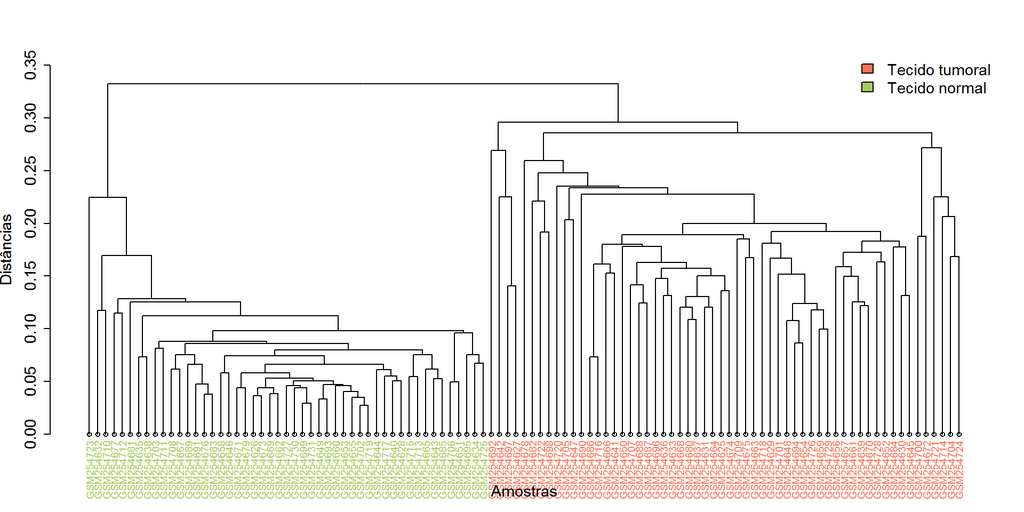

```r
clusDendro = dendrapply(as.dendrogram(cl.hier), colLab)
par(cex = 0.6); plot(clusDendro, axes = F, ylim = c(0, 0.35))
par(cex = 0.9); title(xlab="Amostras", ylab="Distâncias", main = NULL); axis(2)
legend('topright', c('Tecido tumoral', 'Tecido normal'), fill = c('coral1', 'darkolivegreen3'), bty = "n")
```

Analisando o gráfico verifica-se a formação de dois clusters evidentes, estando as amostras de tecido tumoral e tecido normal em ramos diferentes da árvore. Isto significa que os genes provenientes de tecido tumoral apresentam, no geral, um nível de expressão mais próximo entre si do que em relação aos genes provenientes de tecido normal. Isto vai de encontro ao esperado, já que o adenocarcinoma apresenta caraterísticas próprias que vão depender da sobrexpressão de alguns genes (relacionados com a multiplicação celular, mitose, etc.) e subexpressão de outros (relacionados com a adesão celular, mitofagia, etc.), havendo assim diferenças na expressão entre os dois tecidos.

De seguida realizou-se uma análise de clustering tanto para amostras, semelhante ao que foi feito, como para as sondas, isto é, aplicando o clustering às colunas e linhas. Assim, definiram-se duas funções auxiliares, uma para cálculo da matriz de distâncias e outra para o clustering, necessárias para a criação do *heatmap*.

Função auxiliar para cálculo da matriz de distâncias:

```r
dist.fun = function(x) {
  return (as.dist (1 - cor(t (x), method = "pearson")))
}
```

Função auxiliar para realização do clustering hierárquico:

```r
clust.fun = function (x) {
  return (hclust (x, method = "average"))
}
```

Uma outra função foi também definida de modo a poder ser aplicada no *heatmap* para associar uma cor a cada tipo de tecido, nomeadamente verde para amostras de tecido tumoral e amarelo para amostras de tecido normal.

```r
color.map.tissue <- function(tissue) { if (tissue == "tumor") "darkolivegreen3" else "lightgoldenrod1" }
tissuecolors <- unlist(lapply(eset.f$tissue, color.map.tissue))
```

Definindo previamente todas estas funções o *heatmap* pode então ser criado:

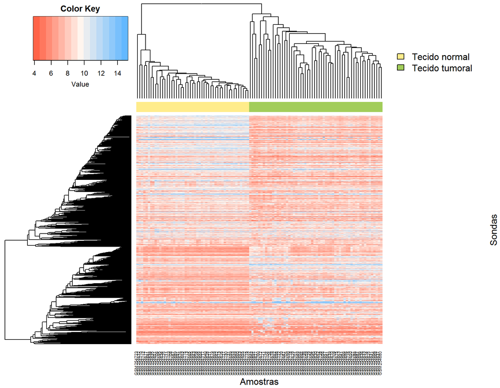

```r
heatmap.2(exprs(eset.f), col = colorRampPalette(c("tomato", "seashell1", "steelblue1")), scale = "none",
          ColSideColors = tissuecolors, key = TRUE, symkey = FALSE, density.info = "none", trace = "none",
          cexRow = 0.5, distfun = dist.fun, hclustfun = clust.fun, labRow = F, margins = c(6,16),
          ylab = "Sondas", xlab = "Amostras")

legend('topright', c("Tecido normal","Tecido tumoral"), bty = "n", fill = c("lightgoldenrod1", "darkolivegreen3"))
```

# 6 Análise Preditiva

Uma análise preditiva foi realizada para previsão tanto do tipo de tecido (tumor/normal) como para o perfil do indivíduo (atual/antigo ou nunca fumador). Para tal usou-se o package *MLInterfaces* (Carey et al. 2016), que disponibiliza uma forma standard de parametrização e apresentação de resultados dos algoritmos de aprendizagem. Na análise usaram-se os métodos de *machine learning* de K-vizinhos mais próximos, árvores de regressão e máquinas de vetores de suporte (SVMs), usando o método de validação cruzada que permite o uso de todos os dados disponíveis. O número de iterações para a validação cruzada foi definido como 10.

## 6.1 K-vizinhos mais próximos

**Previsão de tipo de tecido**

Construção do modelo e resultados:

```r
knnResult.tissue.cv <- MLearn(tissue ~ ., eset.f, knnI(k = 1), xvalSpec("LOG", 10, balKfold.xvspec(10)))
addmargins(confuMat(knnResult.tissue.cv))
```

```
##         predicted
## given    normal tumor Sum
##   normal     48     1  49
##   tumor       0    58  58
##   Sum        48    59 107
```

Precisão do modelo para previsão do tipo de tecido:

```r
precision(confuMat(knnResult.tissue.cv))
```

```
## normal  tumor
## 0.9796 1.0000
```

**Previsão do perfil do indivíduo**

Construção do modelo e resultados:

```r
knnResult.indivs.cv <- MLearn(individual ~ ., eset.f, knnI(k = 1), xvalSpec("LOG", 10, balKfold.xvspec(10)))
addmargins(confuMat(knnResult.indivs.cv))
```

```
##                 predicted
## given            current smoker former smoker never smoker Sum
##   current smoker             19            11           10  40
##   former smoker               9            10           17  36
##   never smoker                4             9           18  31
##   Sum                        32            30           45 107
```

Precisão do modelo para previsão do perfil do indivíduo:

```r
precision(confuMat(knnResult.indivs.cv))
```

```
## current smoker  former smoker   never smoker
##         0.4750         0.2778         0.5806
```

## 6.2 Árvores de regressão

**Previsão de tipo de tecido**

Construção do modelo e resultados:

```r
treeResult.tissue.cv <- MLearn(tissue ~ ., eset.f, rpartI, xvalSpec("LOG", 10, balKfold.xvspec(10)))
addmargins(confuMat(treeResult.tissue.cv))
```

```
##         predicted
## given    normal tumor Sum
##   normal     45     4  49
##   tumor       3    55  58
##   Sum        48    59 107
```

Precisão do modelo para previsão do tipo de tecido:

```r
precision(confuMat(treeResult.tissue.cv))
```

```
## normal  tumor
## 0.9184 0.9483
```

**Previsão do perfil do indivíduo**

Construção do modelo e resultados:

```r
treeResult.indivs.cv <- MLearn(individual ~ ., eset.f, rpartI, xvalSpec("LOG", 10, balKfold.xvspec(10)))
addmargins(confuMat(treeResult.indivs.cv))
```

```
##                 predicted
## given            current smoker former smoker never smoker Sum
##   current smoker             18            13            9  40
##   former smoker              11            16            9  36
##   never smoker                5             9           17  31
##   Sum                        34            38           35 107
```

Precisão do modelo para previsão do perfil do indivíduo:

```r
precision(confuMat(treeResult.indivs.cv))
```

```
## current smoker  former smoker   never smoker
##         0.4500         0.4444         0.5484
```

## 6.3 Máquinas de vetores de suporte (SVMs)

**Previsão de tipo de tecido**

Construção do modelo e resultados:

```r
svmResult.tissue.cv <- MLearn(tissue ~ ., eset.f, svmI , xvalSpec("LOG", 10, balKfold.xvspec(10)))
addmargins(confuMat(svmResult.tissue.cv))
```

```
##         predicted
## given    normal tumor Sum
##   normal     47     2  49
##   tumor       0    58  58
##   Sum        47    60 107
```

Precisão do modelo para previsão do tipo de tecido:

```r
precision(confuMat(svmResult.tissue.cv))
```

```
## normal  tumor
## 0.9592 1.0000
```

**Previsão do perfil do indivíduo**

Construção do modelo e resultados:

```r
svmResult.indivs.cv <- MLearn(individual ~ ., eset.f, svmI , xvalSpec("LOG", 10, balKfold.xvspec(10)))
addmargins(confuMat(svmResult.indivs.cv))
```

```
##                 predicted
## given            current smoker former smoker never smoker Sum
##   current smoker             35             4            1  40
##   former smoker              17             8           11  36
##   never smoker                5            10           16  31
##   Sum                        57            22           28 107
```

Precisão do modelo para previsão do perfil do indivíduo:

```r
precision(confuMat(svmResult.indivs.cv))
```

```
## current smoker  former smoker   never smoker
##         0.8750         0.2222         0.5161
```

De um modo geral, os 3 tipos de modelos utilizados, k-vizinhos mais próximos, árvores de regressão e SVMs, apresentam um bom nível de precisão na previsão do tipo de tecido associado a cada amostra, sendo melhor o método de k-vizinhos mais próximos com um nível de precisão de 97,96% para amostras de tecido normal e 100% para amostras de tecido tumoral. Tal como vimos na análise de clustering, existe uma clara separação entre os dois tipos de tecidos, o que poderá tornar o processo de previsão mais fácil, como vemos aqui.

Por outro lado, o nível de precisão desce consideravelmente quando se trata de prever o perfil do indivíduo associado a cada amostra, estando os níveis de precisão dos três modelos para esta situação por volta e principalmente abaixo dos 50% (com exceção da precisao do modelo de SVM para atuais fumadores, com 87,50%). Neste caso temos mais uma variável a prever do que no caso anterior, o que torna ainda mais complicado o processo de previsão. Além disso, esta diferença na previsão entre tecidos e perfil do indivíduo se deva ao facto de a diferença de expressao ser evidente entre celulas cancerigenas e normais (genes relacionados com ciclo celular, mitose, imunologia, etc.) e esta diferença não ser assim tão evidente quando o que está em causa é se o indivíduo consome ou não tabaco.

# 7 Conclusões

A análise de expressão diferencial em 107 amostras de tecido tumoral e tecido normal provenientes de pacientes atuais, antigos e nunca fumadores demonstrou que existem alterações a nível genético provocadas pelo consumo de tabaco. De facto, em amostras de indivíduos fumadores verificou-se uma maior expressão de genes relacionados com o processo de divisão/ciclo celular, processo de mitose e segregação dos cromossomas na análise com todas as fases tumorais ou apenas primeiras fases (ex. “TTK”, “ECT2”, “CENPF”). Este resultado é consistente com o facto de as células cancerígenas apresentrem um elevado nível de proliferação celular e vai de necontro ao resultado obtido pelos autores deste estudo:

> “We found that smoking induces deregulation of this very mitotic process (…) comprises genes that regulate the mitotic spindle formation (…) such as CENPF. (…) TTK (linked to cell mitosis through EGFR,a critical drug target for lung adenocarcinoma.”

> “In the non-tumor tissue, current smoking strongly altered immune response genes, consistent with the defense mechanisms of the lung tissue against the acute toxic effects of smoking. (…) Our results are consistent with some previous findings, such as smoking-related alteration of CYP1B1”

Uma análise de expressão genética entre antigos fumadores e atuais fumadores demonstrou que, para o critério de significância definido, não existem genes diferencialmente expressos, o que poderá indicar que embora os pacientes já tivessem deixado de fumar há algum tempo as alterações a nível da expressão dos genes se manteve.

Uma outra análise de expressão diferencial entre amostras provenientes de tecido normal e tecido tumoral demonstrou existirem mais genes subexpressos e menos genes sobrexpressos em tecido tumoral, resultado este também evidente pela análise de clustering hierárquico, havendo uma clara separação entre amostras provenientes de tecido tumoral e normal. Da análise de enriquecimento verifica-se que uma existência de “enriquecimento” estatisticamente significativo em genes cujos processos biológicos se relacionam com a divisão celular, ciclo mitótico e processos catabólicos de açúcares, o que está de acordo com o esperado já que as células cancerígenas evoluem no sentido de alterarem o seu metabolismo de forma a conseguirem uma mais rápida proliferação.

Relativamente aos genes subexpressos verifica-se uma existência de “enriquecimento” estatisticamente significativo em genes cujos processos biológicos se relacionam com o desenvolvimento do sistema cardiovascular/circulatório, morfogénese e desenvolvimento de vasos sanguíneos. Tal como referido, embora possa parecer contraditório relativamente ao que se sabe sobre o cancro, nomeadamente no que toca ao aumento do mecanismo de angiogénese, sabe-se que em alguns tipos de cancro o mecanismo de angiogénese não é assim tão relevante e é, em muitos casos, diminuido, pelo que o adenocarcinoma pulmonar poderá ser um desses casos.

Realizada uma análise preditiva usando os métodos de k-vizinhos mais próximos, árvores de regressão e SVMs conclui-se que os métodos apresentam muito boa precisão no que toca à previsão do tecido associado cada amostra, sendo melhor na previsão o método de k-vizinhos mais próximos com um nível de precisão de 97,96% para amostras de tecido normal e 100% para amostras de tecido tumoral. No entanto, para previsão do perfil do indivíduo associado a cada amostra tal não se verifica, estando os níveis de precisão dos três modelos para esta situação por volta e principalmente abaixo dos 50% (com exceção da precisao do modelo de SVM para atuais fumadores, com 87,50%), o que se poderá dever à existência de uma clara separação entre os genes expressos nos dois tipos de tecido, como se verificou na análise de clustering, o que não será assim tão evidente quando se trata de distinguir entre os perfis dos indivíduos.

Referências

Andrés, Olga, Thomas Kellermann, Francesc López-Giráldez, Julio Rozas, Xavier Domingo-Roura, and Montserrat Bosch. 2008. “RPS4Y Gene Family Evolution in Primates.” *BMC Evolutionary Biology* 8 (1). BioMed Central: 1.

Annibaldi, Alessandro, and Christian Widmann. 2010. “Glucose Metabolism in Cancer Cells.” *Current Opinion in Clinical Nutrition & Metabolic Care* 13 (4). LWW: 466–70.

Boneberg, EM, DF Legler, MM Hoefer, C Öhlschlegel, H Steininger, L Füzesi, GM Beer, et al. 2009. “Angiogenesis and Lymphangiogenesis Are Downregulated in Primary Breast Cancer.” *British Journal of Cancer* 101 (4). Nature Publishing Group: 605–14.

Boulay, Gaylor, Nicolas Malaquin, Ingrid Loison, Bénédicte Foveau, Capucine Van Rechem, Brian R Rood, Albin Pourtier, and Dominique Leprince. 2012. “Loss of Hypermethylated in Cancer 1 (HIC1) in Breast Cancer Cells Contributes to Stress-Induced Migration and Invasion Through $\beta$-2 Adrenergic Receptor (ADRB2) Misregulation.” *Journal of Biological Chemistry* 287 (8). ASBMB: 5379–89.

Carey, Vince, Robert Gentleman, Jess Mar, contributions from Jason Vertrees, and Laurent Gatto. 2016. *MLInterfaces: Uniform Interfaces to R Machine Learning Procedures for Data in Bioconductor Containers*.

Catsburg, Chelsea, Victoria A Kirsh, Colin L Soskolne, Nancy Kreiger, and Thomas E Rohan. 2014. “Active Cigarette Smoking and the Risk of Breast Cancer: A Cohort Study.” *Cancer Epidemiology* 38 (4). Elsevier: 376–81.

Falcon, Seth, and Robert Gentleman. 2007. “Using GOstats to Test Gene Lists for GO Term Association.” *Bioinformatics* 23 (2). Oxford Univ Press: 257–58.

Hou, X, JE Liu, W Liu, CY Liu, ZY Liu, and ZY Sun. 2011. “A New Role of NUAK1: Directly Phosphorylating P53 and Regulating Cell Proliferation.” *Oncogene* 30 (26). Nature Publishing Group: 2933–42.

Lampe, Johanna W, Sergey B Stepaniants, Mao Mao, Jerald P Radich, Hongyue Dai, Peter S Linsley, Stephen H Friend, and John D Potter. 2004. “Signatures of Environmental Exposures Using Peripheral Leukocyte Gene Expression: Tobacco Smoke.” *Cancer Epidemiology Biomarkers & Prevention* 13 (3). AACR: 445–53.

Landi, Maria Teresa, Tatiana Dracheva, Melissa Rotunno, Jonine D Figueroa, Huaitian Liu, Abhijit Dasgupta, Felecia E Mann, et al. 2008. “Gene Expression Signature of Cigarette Smoking and Its Role in Lung Adenocarcinoma Development and Survival.” *PloS One* 3 (2). Public Library of Science: e1651.

Liao, H, RJ Winkfein, G Mack, JB Rattner, and TJ Yen. 1995. “CENP-F Is a Protein of the Nuclear Matrix That Assembles onto Kinetochores at Late G2 and Is Rapidly Degraded After Mitosis.” *The Journal of Cell Biology* 130 (3). Rockefeller Univ Press: 507–18.

Lories, Veerle, Jean-Jacques Cassiman, Herman Van den Berghe, and Guido David. 1992. “Differential Expression of Cell Surface Heparan Sulfate Proteoglycans in Human Mammary Epithelial Cells and Lung Fibroblasts.” *Journal of Biological Chemistry* 267 (2). ASBMB: 1116–22.

Mills, Gordon Brent, Rosemarie Schmandt, Martha McGill, Antonella Amendola, Mary Hill, Kathleen Jacobs, Christopher May, Anna-Marie Rodricks, Susan Campbell, and David Hogg. 1992. “Expression of TTK, a Novel Human Protein Kinase, Is Associated with Cell Proliferation.” *Journal of Biological Chemistry* 267 (22). ASBMB: 16000–16006.

Nishiyama, Hiroyuki, Hiroaki Higashitsuji, Hiromichi Yokoi, Katsuhiko Itoh, Shozo Danno, Tadashi Matsuda, and Jun Fujita. 1997. “Cloning and Characterization of Human CIRP (Cold-Inducible RNA-Binding Protein) CDNA and Chromosomal Assignment of the Gene.” *Gene* 204 (1). Elsevier: 115–20.

Rezvani, Katayoun, and A John Barrett. 2008. “Characterizing and Optimizing Immune Responses to Leukaemia Antigens After Allogeneic Stem Cell Transplantation.” *Best Practice & Research Clinical Haematology* 21 (3). Elsevier: 437–53.

Ritchie, Matthew E, Belinda Phipson, Di Wu, Yifang Hu, Charity W Law, Wei Shi, and Gordon K Smyth. 2015. “Limma Powers Differential Expression Analyses for RNA-Sequencing and Microarray Studies.” *Nucleic Acids Research*. Oxford Univ Press, gkv007.

Rosinski, Kellie V, Nobuharu Fujii, Jeffrey K Mito, Kevin KW Koo, Suzanne M Xuereb, Olga Sala-Torra, James S Gibbs, et al. 2008. “DDX3Y Encodes a Class I MHC–restricted HY Antigen That Is Expressed in Leukemic Stem Cells.” *Blood* 111 (9). Am Soc Hematology: 4817–26.

Subramanian, Janakiraman, and Ramaswamy Govindan. 2007. “Lung Cancer in Never Smokers: A Review.” *Journal of Clinical Oncology* 25 (5). American Society of Clinical Oncology: 561–70.

Superti-Furga, A, M Rocchi, BW Schäfer, and R Gitzelmann. 1993. “Complementary DNA Sequence and Chromosomal Mapping of a Human Proteoglycan-Binding Cell-Adhesion Protein (Dermatopontin).” *Genomics* 17 (2). Elsevier: 463–67.

Tatsumoto, Takashi, Xiaozhen Xie, Rayah Blumenthal, Isamu Okamoto, and Toru Miki. 1999. “Human ECT2 Is an Exchange Factor for Rho GTPases, Phosphorylated in G2/M Phases, and Involved in Cytokinesis.” *The Journal of Cell Biology* 147 (5). Rockefeller Univ Press: 921–28.

Thiesen, Signe, S Kübart, H-H Ropers, and HG Nothwang. 2000. “Isolation of Two Novel Human RhoGEFs, ARHGEF3 and ARHGEF4, in 3p13-21 and 2q22.” *Biochemical and Biophysical Research Communications* 273 (1). Elsevier: 364–69.